# StanとRStanをはじめよう

月元 敬

2018年9月11日

# 記述の例

標準偏差$1$の正規分布をデータ$Y$に当てはめる。未知のパラメータ$\mu$は無情報事前分布に従うと考える。

$$Y[n] \sim Normal(\mu, 1)$$
$$\mu \sim Normal(0, 100)$$

```
data{
  int N;
  real Y[N];
}

parameters{
  real mu;
}

model{
  for(n in 1:N){
    Y[n] ~ normal(mu, 1);
  }
  mu ~ normal(0, 100);
}
```

muの事前分布に指定を省略してもStanでは，十分に幅の広い一様分布が使われるため動く。

> Advanced（ここから）

Stanの内部では事後確率そのものではなく対数事後確率
$$\log p(\theta | Y) = \log p(Y | \theta) + \log p(\theta) + const.$$
をlp__という名前で保持している。内部的な仕組みに留意して，「target」というlp__のニックネームを使うStanコードの書き方もある。

$$p(\mu | Y) \propto p(Y | \mu) \times p(\mu) = \left[ \prod_{n=1}^{20} Normal(Y[n] | \mu, 1) \right] \times Normal(\mu | 0, 100)$$

右辺の対数を取るとlp__になる。

$$\left[ \sum_{n=1}^{20} \log Normal(Y[n] |\mu, 1) \right] + \log Normal(\mu | 0, 100)$$

modelブロックは次のようになる。

```
model{
  for(i in 1:N){
    target += normal_lpdf(Y[n] | mu, 1);    //lpdf = 対数確率密度関数
  }
  target += normal_lpdf(mu | 0, 100);
}
```

この記法は高度なモデルで必要になる。

> Advanced（ここまで）

## 単回帰

社員の年齢$X$（歳）と年収$Y$（万円）に関する架空データを扱う。

```r
d = read.csv("data-salary.csv")
d
```

```
##     X    Y
## 1  24  472
## 2  24  403
## 3  26  454
## 4  32  575
## 5  33  546
## 6  35  781
## 7  38  750
## 8  40  601
## 9  40  814
## 10 43  792
## 11 43  745
## 12 44  837
## 13 48  868
## 14 52  988
## 15 56 1092
## 16 56 1007
## 17 57 1233
## 18 58 1202
## 19 59 1123
## 20 59 1314
```

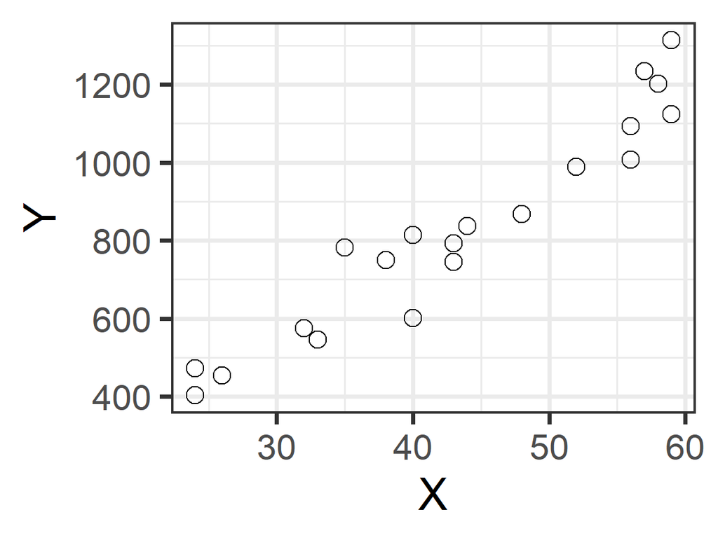

```r
library(ggplot2)
d = read.csv('data-salary.csv')
p = ggplot(data = d, aes(x = X, y = Y))
p = p + theme_bw(base_size = 18)
p = p + geom_point(shape = 1, size = 3)
ggsave(file='fig4-2.png', plot = p, dpi = 300, w = 4, h = 3)
```

直線当てはめに無理はなさそう。

### lm関数で推定

単純な例の場合，最尤推定による予測分布とベイズ推定による予測分布はほとんど違いがないが，まずは従来的な直線当てはめを行う。

```r
res_lm = lm(Y ~ X, data = d)
summary(res_lm)
```

```
##
## Call:
## lm(formula = Y ~ X, data = d)
##
## Residuals:
##      Min       1Q   Median       3Q      Max
## -155.471  -51.523   -6.663   52.822  141.349
##
## Coefficients:
##             Estimate Std. Error t value Pr(>|t|)
## (Intercept) -119.697     68.148  -1.756    0.096 .
## X             21.904      1.518  14.428 2.47e-11 ***
## ---
## Signif. codes:  0 '***' 0.001 '**' 0.01 '*' 0.05 '.' 0.1 ' ' 1
##
## Residual standard error: 79.1 on 18 degrees of freedom
## Multiple R-squared:  0.9204, Adjusted R-squared:  0.916
## F-statistic: 208.2 on 1 and 18 DF,  p-value: 2.466e-11
```

回帰直線が$Y = -119.7 + 21.9X$と推定された。lm関数の結果を使うと，パラメータの信頼区間と新しいデータの予測区間は次のスクリプトで求められる。

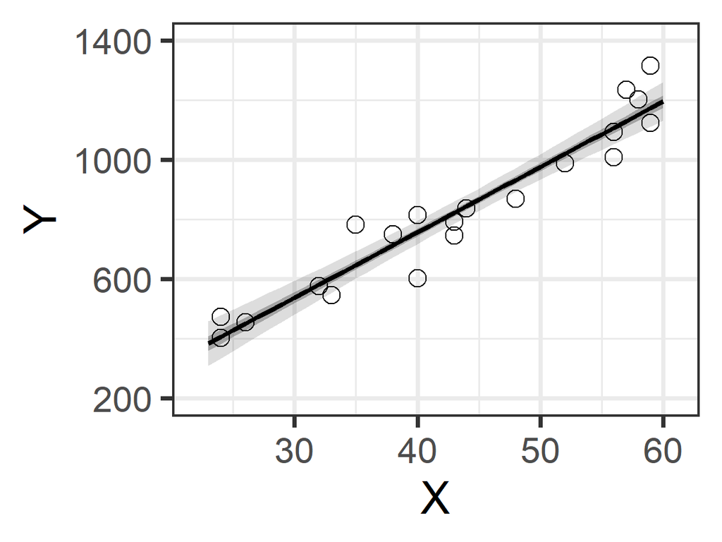

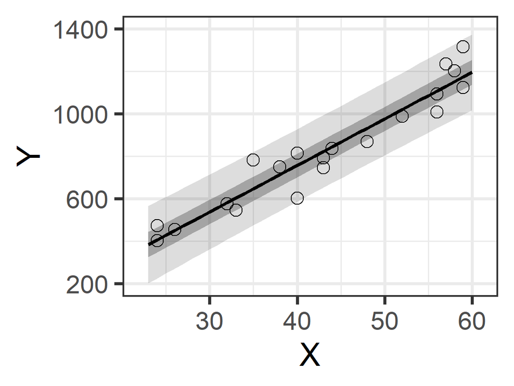

```r
X_new = data.frame(X = 23:60)
conf_95 = predict(res_lm, X_new, interval = 'confidence', level = 0.95)
conf_95 = data.frame(X_new, conf_95)
conf_50 = predict(res_lm, X_new, interval = 'confidence', level = 0.50)
conf_50 = data.frame(X_new, conf_50)
pred_95 = predict(res_lm, X_new, interval = 'prediction', level = 0.95)
pred_95 = data.frame(X_new, pred_95)
pred_50 = predict(res_lm, X_new, interval = 'prediction', level = 0.50)
pred_50 = data.frame(X_new, pred_50)

library(ggplot2)

p = ggplot()
p = p + theme_bw(base_size = 18)
p = p + geom_ribbon(data = conf_95, aes(x = X, ymin = lwr, ymax = upr), alpha = 1/6)
p = p + geom_ribbon(data = conf_50, aes(x = X, ymin = lwr, ymax = upr), alpha = 2/6)
p = p + geom_line(data = conf_50, aes(x = X, y = fit), size = 1)
p = p + geom_point(data = d, aes(x = X, y = Y), shape = 1, size = 3)
p = p + labs(x = 'X', y = 'Y') + coord_cartesian(xlim = c(22, 61), ylim = c(200, 1400))
p = p + scale_y_continuous(breaks = seq(from = 200, to = 1400, by = 400))
ggsave(p, file = 'fig4-3-left.png', dpi = 300, w = 4, h = 3)

p = ggplot()
p = p + theme_bw(base_size = 18)
p = p + geom_ribbon(data = pred_95, aes(x = X, ymin = lwr, ymax = upr), alpha = 1/6)
p = p + geom_ribbon(data = pred_50, aes(x = X, ymin = lwr, ymax = upr), alpha = 2/6)
p = p + geom_line(data = pred_50, aes(x = X, y = fit), size = 1)
p = p + geom_point(data = d, aes(x = X, y = Y), shape = 1, size = 3)
p = p + labs(x = 'X', y = 'Y') + coord_cartesian(xlim = c(22, 61), ylim = c(200, 1400))
p = p + scale_y_continuous(breaks = seq(from = 200, to = 1400, by = 400))
ggsave(p, file = 'fig4-3-right.png', dpi = 300, w = 4, h = 3)
```

予測区間内にデータが分布しているので，うまく予測できていると言える。

### Stanで実装

$N$を人数としたモデル式は次のように書くことができる。

$$Y[n] = y_{base}[n] + \varepsilon[n]$$
$$y_{base}[n] = a + bX[n]$$
$$\varepsilon[n] \sim Normal(0, \sigma)$$

ベイズ統計では$a$，$b$，$\sigma$の事前分布を設定する必要があるが，十分に幅の広い一様分布を無情報事前分布とすれば，Stanでは省略できる。

また，上記の式は数学で許される手続きにより，次のように書き換えが可能である。

##### 書き換え1（$y_{base}[n]$を消去）

$$Y[n] = a + bX[n] + \varepsilon[n]$$
$$\varepsilon[n] \sim Normal(0, \sigma)$$

##### 書き換え2（$\varepsilon[n]$を消去）

$$y_{base}[n] = a + bX[n]$$
$$Y[n] \sim Normal(y_{base}[n], \sigma)$$

##### 書き換え3（$y_{base}[n]$と$\varepsilon[n]$を消去）

$$Y[n] \sim Normal(a + bX[n], \sigma)$$

Stanでは$\varepsilon[n]$を消去した記法が計算が高速になるが，収束しにくくなる場合もある。

##### model4-5.stan

```
data{
  int N;
  real X[N];
  real Y[N];
}

parameters{
  real a;
  real b;
  real<lower=0> sigma;
}

model{
  for(n in 1:N){
    Y[n] ~ normal(a + b*X[n], sigma);
  }
}
```

##### run-model4-5.R

```r
library(rstan)
d = read.csv('data-salary.csv')
data = list(N = nrow(d), X = d$X, Y = d$Y)
fit = stan(file = 'model4-5.stan', data = data, seed = 1234)
```

[output not shown]

[output cut: 61 more lines]

```
## Iteration:  200 / 2000 [ 10%]  (Warmup)
## Iteration:  400 / 2000 [ 20%]  (Warmup)
## Iteration:  600 / 2000 [ 30%]  (Warmup)
## Iteration:  800 / 2000 [ 40%]  (Warmup)
## Iteration: 1000 / 2000 [ 50%]  (Warmup)
## Iteration: 1001 / 2000 [ 50%]  (Sampling)
## Iteration: 1200 / 2000 [ 60%]  (Sampling)
## Iteration: 1400 / 2000 [ 70%]  (Sampling)
## Iteration: 1600 / 2000 [ 80%]  (Sampling)
## Iteration: 1800 / 2000 [ 90%]  (Sampling)
## Iteration: 2000 / 2000 [100%]  (Sampling)
##
##  Elapsed Time: 0.213 seconds (Warm-up)
##                0.104 seconds (Sampling)
##                0.317 seconds (Total)
```

```r
save.image(file = 'result-model4-5.RData')
```

```r
fit
```

```
## Inference for Stan model: model4-5.
## 4 chains, each with iter=2000; warmup=1000; thin=1;
## post-warmup draws per chain=1000, total post-warmup draws=4000.
##
##          mean se_mean    sd    2.5%     25%     50%    75%  97.5% n_eff
## a     -117.73    2.25 72.40 -265.09 -163.59 -117.33 -70.23  23.98  1035
## b       21.87    0.05  1.61   18.77   20.80   21.89  22.88  25.18  1054
## sigma   85.27    0.40 15.36   62.00   74.49   83.11  94.02 122.23  1475
## lp__   -93.60    0.04  1.29  -96.94  -94.17  -93.26 -92.67 -92.15  1114
##       Rhat
## a        1
## b        1
## sigma    1
## lp__     1
##
## Samples were drawn using NUTS(diag_e) at Tue Sep 11 14:08:04 2018.
## For each parameter, n_eff is a crude measure of effective sample size,
## and Rhat is the potential scale reduction factor on split chains (at
## convergence, Rhat=1).
```

各パラメータにおけるMCMCサンプルの平均値，標準誤差，標準偏差，分位点（ベイズ信頼区間），実効的サンプル数，$\hat{R}$が出力される。「chain数が3以上で全てのパラメータで$\hat{R} < 1.1$となること」で収束と見なす。収束するまでモデルの試行錯誤を繰り返す必要がある。

### 収束診断

ggmcmcパッケージはggplot2を利用したMCMCの収束を診断するためのパッケージである。事前にインストールしておく必要がある。

##### rstan-save-diagnostics.R

```r
library(rstan)
library(ggmcmc)
```

```r
load('result-model4-5.RData')

write.table(data.frame(summary(fit)$summary),
            file = 'fit-summary.txt', sep = '\t', quote = FALSE, col.names = NA)

ggmcmc(ggs(fit, inc_warmup = TRUE, stan_include_auxiliar = TRUE),
       file = 'fit-traceplot.pdf', plot = 'traceplot')
```

```
## Plotting traceplots
```

```
## Time taken to generate the report: 1.5 seconds.
```

```r
ggmcmc(ggs(fit), file = 'fit-ggmcmc.pdf')
```

```
## Plotting histograms
```

```
## Plotting density plots
```

```
## Plotting traceplots
```

```
## Plotting running means
```

```
## Plotting comparison of partial and full chain
```

```
## Plotting autocorrelation plots
```

```
## Plotting crosscorrelation plot
```

```
## Plotting Potential Scale Reduction Factors
```

```
## Plotting Geweke Diagnostic
```

```
## Plotting caterpillar plot
## Time taken to generate the report: 11 seconds.
```

```r
# ggmcmc(ggs(fit), file = 'fit-ggmcmc.pdf',
#   plot = c('traceplot', 'density', 'running', 'autocorrelation'))
```

fit-summary.txtにはfitにある各パラメータの要約が出力されている。fit-traceplot.pdfには各パラメータのトレースプロットが出力されている。いずれのchainもステップ数が200を超えると収束していると言える（warmupは300ぐらいで十分そう）。

fit-ggmcmc.pdfにはMCMCサンプルのヒストグラム，密度関数，トレースプロット，事後平均の推移，chainの一部と全体の密度関数の比較，自己相関，パラメータ間の相関行列，$\hat{R}$，Geweke z-scoreが出力されている。

パラメータ数が1000を超えるような場合，PCのスペック次第では相関行列の算出でメモリ不足となり，Rが落ちる可能性が高い。コメントアウトしている部分は出力内容を限定する場合のコマンドである。

## MCMCの設定変更

##### rstan-modify-MCMCsettings.R

```r
library(rstan)

d = read.csv(file = 'data-salary.csv')
data = list(N = nrow(d), X = d$X, Y = d$Y)

stanmodel = stan_model(file = 'model4-5.stan')  #モデルファイルのコンパイル

#sampling関数はstan関数で一括して行っていたコンパイルとサンプリングのうち，サンプリングのみを実行する
fit = sampling(
  stanmodel,
  data = data,
  pars = c('b', 'sigma'),   #保存したいパラメータ名を指定

  #初期値の設定
  init = function(){
    list(a = runif(1, -10, 10), b = runif(1, 0, 10), sigma = 10)
  },
  seed = 123,
  chains = 3, iter = 1000, warmup = 200, thin = 2
)
```

[output not shown]

[output cut: 16 more lines]

[output not shown]

局所最適に陥って現実的な時間で抜け出せなくなる場合はモデル改善の他，初期値設定という手もある。

MCMCでのステップ数などについて，

- chainsは最低3（Stan開発チームは4を推奨）
- iterはモデルの試行錯誤段階では500～1000で実行し，最終モデルが決まれば大きくする（1000～5000）。
- warmupはトレースプロットを見て決める。
- thinは通常1でよい。しかし，一時的に急激に値が変わるようなトレースプロットが見られる場合はthinの値を5などに増やして自己相関を減らすと，収束がよくなることがある。

> Advanced（ここから）

stan関数などの関数を呼ぶ前に次のコードを書いておくと，サンプリングを並列処理化することができる。

```r
rstan_options(auto_write = TRUE)
options(mc.cores = parallel::detectCores())
```

> Advanced（ここまで）

## ベイズ信頼区間とベイズ予測区間

##### rstan-extract-MCMCsamples.R（1行目～3行目）

```r
load('result-model4-5.RData')

ms = rstan::extract(fit)    #他のパッケージにもあるextract関数と衝突しないようにする
```

msは名前付きリストになっているので，ここから各パラメータのMCMCサンプルを取り出すことができる。パラメータ$b$のベイズ信頼区間は次の通り。

```r
quantile(ms$b, probs = c(0.025, 0.095))   #ms$bはwarmup期間を除外したMCMCサンプル
```

```
##     2.5%     9.5%
## 18.77446 19.79421
```

MCMCサンプルは事後分布$p(a, b, \sigma | X, Y)$からサンプリングされたものである。事後分布は同時分布であるから，これを俯瞰できる図（散布図，周辺分布）を作成する。

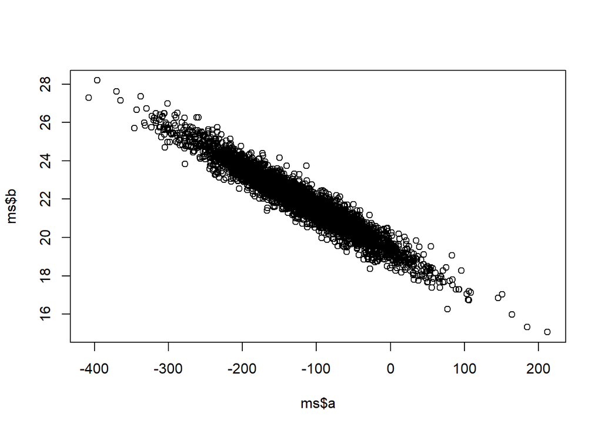

```r
plot(ms$a, ms$b)
```

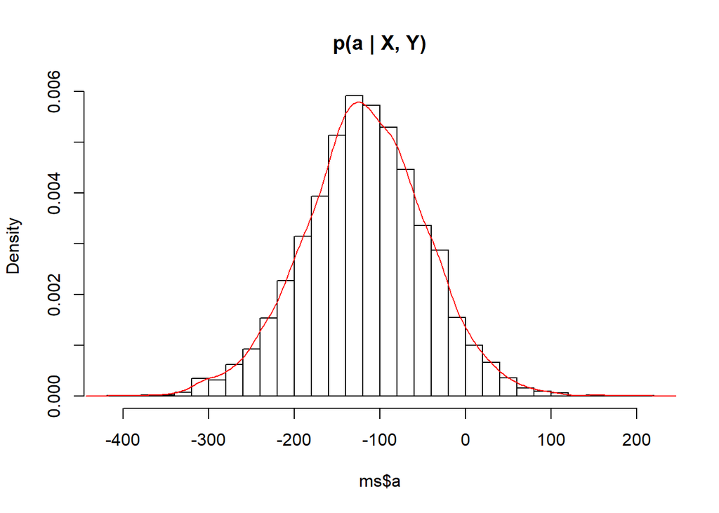

```r
hist(ms$a, breaks ="Scott", probability = TRUE, main = "p(a | X, Y)")
lines(density(ms$a), col = "red")
```

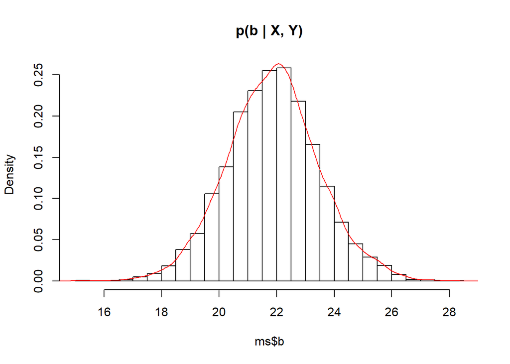

```r
hist(ms$b, breaks ="Scott", probability = TRUE, main = "p(b | X, Y)")
lines(density(ms$b), col = "red")
```

ggplot2を使いこなせると次のような図ができるそうだが，公開コードではうまく作図できなかった。。。

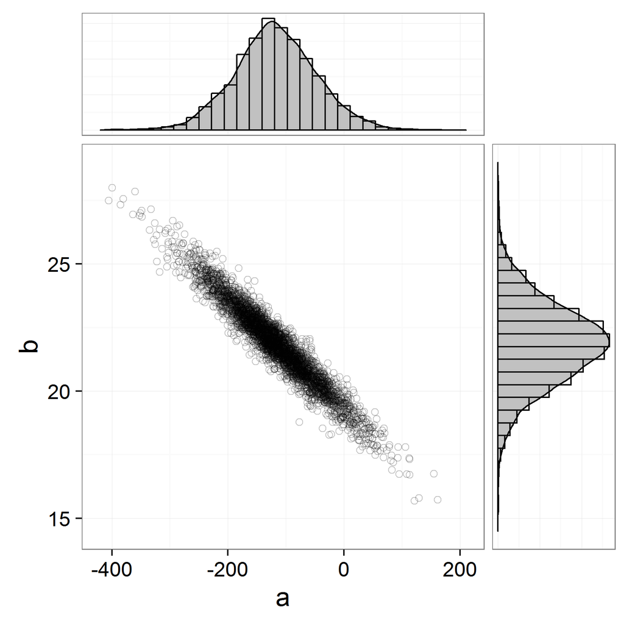

##### rstan-extract-MCMCsamples.R（4行目～7行目）

```r
N_mcmc = length(ms$lp__)    #MCMCサンプルの長さ
y50_base = ms$a + ms$b * 50   #50歳の基本年収の分布
y50 = rnorm(n = N_mcmc, mean = y50_base, sd = ms$sigma)
d_mcmc = data.frame(a = ms$a, b = ms$b, sigma = ms$sigma, y50_base, y50)
```

ベイズ予測区間も簡単に求めることができる。

```r
quantile(y50, probs = c(0.025, 0.095))
```

```
##     2.5%     9.5%
## 800.2308 859.2014
```

23歳～60歳でもベイズ信頼区間とベイズ予測区間を図示できる。

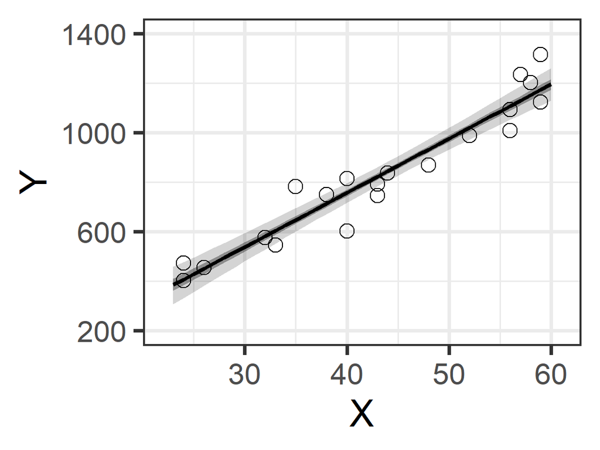

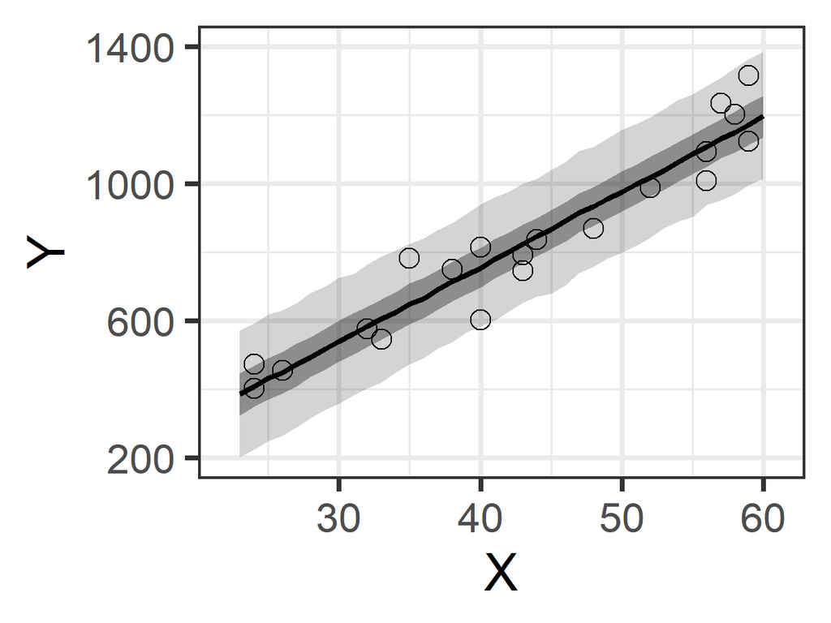

```r
library(ggplot2)
source('common.R')

load('result-model4-5.RData')
ms = rstan::extract(fit)

X_new = 23:60
N_X = length(X_new)
N_mcmc = length(ms$lp__)

set.seed(1234)
y_base_mcmc = as.data.frame(matrix(nrow = N_mcmc, ncol = N_X))
y_mcmc = as.data.frame(matrix(nrow = N_mcmc, ncol = N_X))
for(i in 1:N_X){
  y_base_mcmc[, i] = ms$a + ms$b * X_new[i]
  y_mcmc[, i] = rnorm(n = N_mcmc, mean = y_base_mcmc[, i], sd = ms$sigma)
}

customize.ggplot.axis = function(p){
  p = p + labs(x = 'X', y = 'Y')
  p = p + scale_y_continuous(breaks = seq(from = 200, to = 1400, by = 400))
  p = p + coord_cartesian(xlim = c(22, 61), ylim = c(200, 1400))
  return(p)
}

d_est = data.frame.quantile.mcmc(x = X_new, y_mcmc = y_base_mcmc)
p = ggplot.5quantile(data = d_est)
p = p + geom_point(data = d, aes(x = X, y = Y), shape = 1, size = 3)
p = customize.ggplot.axis(p)
ggsave(file = 'fig4-8-left.png', plot = p, dpi = 300, w = 4, h = 3)

d_est = data.frame.quantile.mcmc(x = X_new, y_mcmc = y_mcmc)
p = ggplot.5quantile(data = d_est)
p = p + geom_point(data = d, aes(x = X, y = Y), shape = 1, size = 3)
p = customize.ggplot.axis(p)
ggsave(file = 'fig4-8-right.png', plot = p, dpi = 300, w = 4, h = 3)
```

なお，濃い帯は$50\%$区間で，黒線は中央値。